# Exploring_Hurricane_Data_1

[output not shown]

## Atlantic Hurricane Data

The package `"dplyr"` contains a dataset called `storms` which is a subset of the *NOAA Atlantic hurricane database best track data*. This database is one of several data sets available in the National Hurricane Center (NHC) Data Archive, which is part of the National Oceanic and Atmospheric Administration (NOAA). In case you are curious about the specifications and format of this type of data, outside of class you can visit the following link:

http://www.nhc.noaa.gov/data/#hurdat

The data `storms` includes the positions and attributes of 198 tropical storms, measured every six hours during the lifetime of a storm. These data are at your finger tips! We’re ultimately going to use these data to better understand how hurricanes behave, and how that has shifted with climate change.

### Assignment

1. Let’s start with a prediction: Do you think that hurricanes have occurred every year in recent history? Provide a one-sentence explanation for your prediction. (Note, your prediction does not have to be correct to get credit here)

Prediction: We predict that hurricanes every year, because meteorologists talk about a hurricane season every year.

Now that your prediction is documented, let’s get a preview of the data. To do so, type the name of the data object, like this:

```r
storms
```

```
## # A tibble: 10,010 × 13
##    name   year month   day  hour   lat  long status      category  wind pressure
##    <chr> <dbl> <dbl> <int> <dbl> <dbl> <dbl> <chr>       <ord>    <int>    <int>
##  1 Amy    1975     6    27     0  27.5 -79   tropical d… -1          25     1013
##  2 Amy    1975     6    27     6  28.5 -79   tropical d… -1          25     1013
##  3 Amy    1975     6    27    12  29.5 -79   tropical d… -1          25     1013
##  4 Amy    1975     6    27    18  30.5 -79   tropical d… -1          25     1013
##  5 Amy    1975     6    28     0  31.5 -78.8 tropical d… -1          25     1012
##  6 Amy    1975     6    28     6  32.4 -78.7 tropical d… -1          25     1012
##  7 Amy    1975     6    28    12  33.3 -78   tropical d… -1          25     1011
##  8 Amy    1975     6    28    18  34   -77   tropical d… -1          30     1006
##  9 Amy    1975     6    29     0  34.4 -75.8 tropical s… 0           35     1004
## 10 Amy    1975     6    29     6  34   -74.8 tropical s… 0           40     1002
## # … with 10,000 more rows, and 2 more variables: ts_diameter <dbl>,
## #   hu_diameter <dbl>
```

What’s going on in the above output?

- `storms` is a **tibble** object, which is one of the data objects in R that handles data in tabular format.
- tibbles are not a native R object—they come from the homonym package `"tibble"`—instead they are a modern version of data frames

The way tibbles are *printed* is very interesting.

- the number of rows that are displayed is limited to 10;
- depending on the width of the printing space, you will only see a few columns shown to fit such width.
- underneath the name of each column there is a three letter abbreviation inside angle brackets
- this abbreviation indicates the *data type* used by R to store the values. For
  - `<chr>` stands for *character* data
  - `<dbl>` means *double* (i.e. real numbers or numbers with decimal digits)
  - `<int>` means *integer* (numbers with no decimal digits)
  - `<ord>` indicates an *ordinal* `factor` which is how R handles categorical data

```r
storms
```

```
## # A tibble: 10,010 × 13
##    name   year month   day  hour   lat  long status      category  wind pressure
##    <chr> <dbl> <dbl> <int> <dbl> <dbl> <dbl> <chr>       <ord>    <int>    <int>
##  1 Amy    1975     6    27     0  27.5 -79   tropical d… -1          25     1013
##  2 Amy    1975     6    27     6  28.5 -79   tropical d… -1          25     1013
##  3 Amy    1975     6    27    12  29.5 -79   tropical d… -1          25     1013
##  4 Amy    1975     6    27    18  30.5 -79   tropical d… -1          25     1013
##  5 Amy    1975     6    28     0  31.5 -78.8 tropical d… -1          25     1012
##  6 Amy    1975     6    28     6  32.4 -78.7 tropical d… -1          25     1012
##  7 Amy    1975     6    28    12  33.3 -78   tropical d… -1          25     1011
##  8 Amy    1975     6    28    18  34   -77   tropical d… -1          30     1006
##  9 Amy    1975     6    29     0  34.4 -75.8 tropical s… 0           35     1004
## 10 Amy    1975     6    29     6  34   -74.8 tropical s… 0           40     1002
## # … with 10,000 more rows, and 2 more variables: ts_diameter <dbl>,
## #   hu_diameter <dbl>
```

```r
str(storms)
```

```
## tibble [10,010 × 13] (S3: tbl_df/tbl/data.frame)
##  $ name       : chr [1:10010] "Amy" "Amy" "Amy" "Amy" ...
##  $ year       : num [1:10010] 1975 1975 1975 1975 1975 ...
##  $ month      : num [1:10010] 6 6 6 6 6 6 6 6 6 6 ...
##  $ day        : int [1:10010] 27 27 27 27 28 28 28 28 29 29 ...
##  $ hour       : num [1:10010] 0 6 12 18 0 6 12 18 0 6 ...
##  $ lat        : num [1:10010] 27.5 28.5 29.5 30.5 31.5 32.4 33.3 34 34.4 34 ...
##  $ long       : num [1:10010] -79 -79 -79 -79 -78.8 -78.7 -78 -77 -75.8 -74.8 ...
##  $ status     : chr [1:10010] "tropical depression" "tropical depression" "tropical depression" "tropical depression" ...
##  $ category   : Ord.factor w/ 7 levels "-1"<"0"<"1"<"2"<..: 1 1 1 1 1 1 1 1 2 2 ...
##  $ wind       : int [1:10010] 25 25 25 25 25 25 25 30 35 40 ...
##  $ pressure   : int [1:10010] 1013 1013 1013 1013 1012 1012 1011 1006 1004 1002 ...
##  $ ts_diameter: num [1:10010] NA NA NA NA NA NA NA NA NA NA ...
##  $ hu_diameter: num [1:10010] NA NA NA NA NA NA NA NA NA NA ...
```

### Assignment

2. Which variable in `storms` describes the Saffir-Simpson storm classification for each storm at each time point?

## Exploratory Data Analysis

Exploring data is very similar to when you go to the doctor and they do an initial exploration (e.g. measuring your height, your weight, temperature, blood pressure; listening to your heart and lungs; looking at your eyes, throat, ears; asking you questions about your eating habits, physical activity habits, etc).

To perform an exploratory analysis of data that is tabular format, we typically start by inspecting each variable (each column) at a time. To keep things relatively simple, we won’t perform a full exploration of every single variable in the data. However, we encourage you to play with the functions to go beyond what we cover in this module. In real life, you will have to do such exploration.

### Basic Inspection of `year`

When you type `storms`, R displays the first 10 rows, which belong to storm Amy in 1975:

```r
storms
```

```
## # A tibble: 10,010 × 13
##    name   year month   day  hour   lat  long status      category  wind pressure
##    <chr> <dbl> <dbl> <int> <dbl> <dbl> <dbl> <chr>       <ord>    <int>    <int>
##  1 Amy    1975     6    27     0  27.5 -79   tropical d… -1          25     1013
##  2 Amy    1975     6    27     6  28.5 -79   tropical d… -1          25     1013
##  3 Amy    1975     6    27    12  29.5 -79   tropical d… -1          25     1013
##  4 Amy    1975     6    27    18  30.5 -79   tropical d… -1          25     1013
##  5 Amy    1975     6    28     0  31.5 -78.8 tropical d… -1          25     1012
##  6 Amy    1975     6    28     6  32.4 -78.7 tropical d… -1          25     1012
##  7 Amy    1975     6    28    12  33.3 -78   tropical d… -1          25     1011
##  8 Amy    1975     6    28    18  34   -77   tropical d… -1          30     1006
##  9 Amy    1975     6    29     0  34.4 -75.8 tropical s… 0           35     1004
## 10 Amy    1975     6    29     6  34   -74.8 tropical s… 0           40     1002
## # … with 10,000 more rows, and 2 more variables: ts_diameter <dbl>,
## #   hu_diameter <dbl>
```

From this output, we know that the data contains at least one storm from 1975.

We also know, from the manual documentation of `storms`, that there are supposed to be 198 storms. But we don’t know for what years. So let’s begin inspecting `storms` by focusing on column `year`. Our first exploratory question is:

> **For what years do we have hurricane data?**

There are several ways in R to manipulate a column from a tabular object. Using `"dplyr"`, there are two basic kinds of functions to extract variables: `pull()` and `select()`.

[figure not shown]

Extracting a column with dplyr functions “pull” and “select”

Let’s do a sanity check of years. We can use the function `pull()` that *pulls* or extracts an entire column. Because there are 10010 elements in `years`, let’s also use `unique()` to find out the set of year values in the data. First we pull the year, and then we identify unique occurrences:

```r
unique(pull(storms, year))
```

```
##  [1] 1975 1976 1977 1978 1979 1980 1981 1982 1983 1984 1985 1986 1987 1988 1989
## [16] 1990 1991 1992 1993 1994 1995 1996 1997 1998 1999 2000 2001 2002 2003 2004
## [31] 2005 2006 2007 2008 2009 2010 2011 2012 2013 2014 2015
```

The same can be accomplished with `select()`. The difference with `pull()` is in the way the output is handled by `select()`, which returns output in a table format:

```r
unique(select(storms, year))
```

```
## # A tibble: 41 × 1
##     year
##    <dbl>
##  1  1975
##  2  1976
##  3  1977
##  4  1978
##  5  1979
##  6  1980
##  7  1981
##  8  1982
##  9  1983
## 10  1984
## # … with 31 more rows
```

### Assignment

3. Based on the data here, was your answer in question 1 correct? Provide a one-sentence explanation.

Yes, based on the output table, there are consecutive years listed for storms.

4. Now, do you think the hurricanes are evenly distributed across those years, or are some years more likely to have more hurricanes? Again, give a one-sentence explanation. (And again, your guess here does not have to be correct)

I think ther are some years more likely to have a hurricane as opposed to others, due to the water currents along the west coast of Africa. (El Nino La Nina)

### Barplot of `year` values

Let’s keep using the values in column `year` to obtain our first visualization with `"ggplot2"` functions. You could certainly begin a visual exploration of other variables, but we think `year` is a good place to start because it’s a numeric variable, measured on a discrete scale, and this is a good candidate to use barcharts (the most popular type of graphic).

`"ggplot2"` comes with a large number of functions to create almost any type of chart. Luckily for us, it already comes with predefined functions to graph barcharts. The syntax may seem a bit scary for beginners, but you will see that it follows a logical structure. Here’s the code to make a barplot of values in `year`:

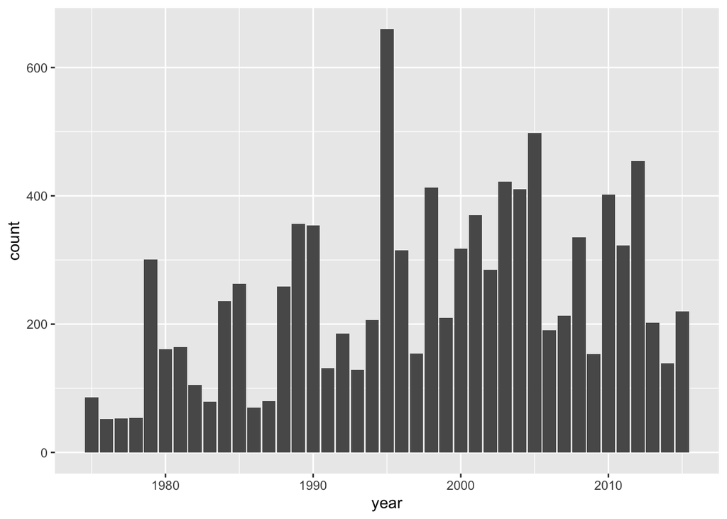

```r
# barchart of year values
ggplot(data = storms) +
  geom_bar(aes(x = year))
```

How does the previous command work?

- First, we always call the `ggplot()` function, typically indicating the name of the table to be used with the `data` argument.
- Then, we add more components, or **layers**, using the plus `+` operator.
- In this case we are adding just one layer: a `geom_bar()` component which is the geometric object for bars.
- To tell `ggplot()` that `year` is the column in `data = storms` to be used for the x-axis, we **map** `x = year` inside the `aes()` function which stands for *aesthetic* mapping.

We should clarify that the meaning of “aesthetic” as used by `"ggplot2"` does not mean beautiful or pretty, instead it conserves its etymological meaning of *perception*. Simply put, `aes()` is the function that you use to tell `ggplot()` which variables of a `data` object will be mapped as visual attributes of graphical elements.

### Assignment

Let’s use similar tools to understand if hurricanes are more likely in a particular month.

5. Guess if hurricanes are evenly distributed through the calendar year, or if they’re more common in some months.

They’re likely more common in some months, probably the summer.

6. Using the techniques above (`pull()`, `select()`, and `unique()`), inspect the values present in the column `month`.

```r
unique(select(storms, month))
```

```
## # A tibble: 10 × 1
##    month
##    <dbl>
##  1     6
##  2     7
##  3     8
##  4     9
##  5    10
##  6    11
##  7    12
##  8     5
##  9     4
## 10     1
```

7. Use `sort()` in order to arrange the unique values of `month`.

```r
sort(unique(pull(storms, month)))
```

```
##  [1]  1  4  5  6  7  8  9 10 11 12
```

8. Are there months for which there seem to be no recorded storm data? Does that mean there’s a problem with how we’re handling the data, or is that expected? Explain.

Yes, there are months with no recorded storm data. Not necessarily a problem with how we’re handling data, but rather just how climate patterns were that year.

9. Use `"ggplot2"` functions to graph a barchart for the values in column `month`.

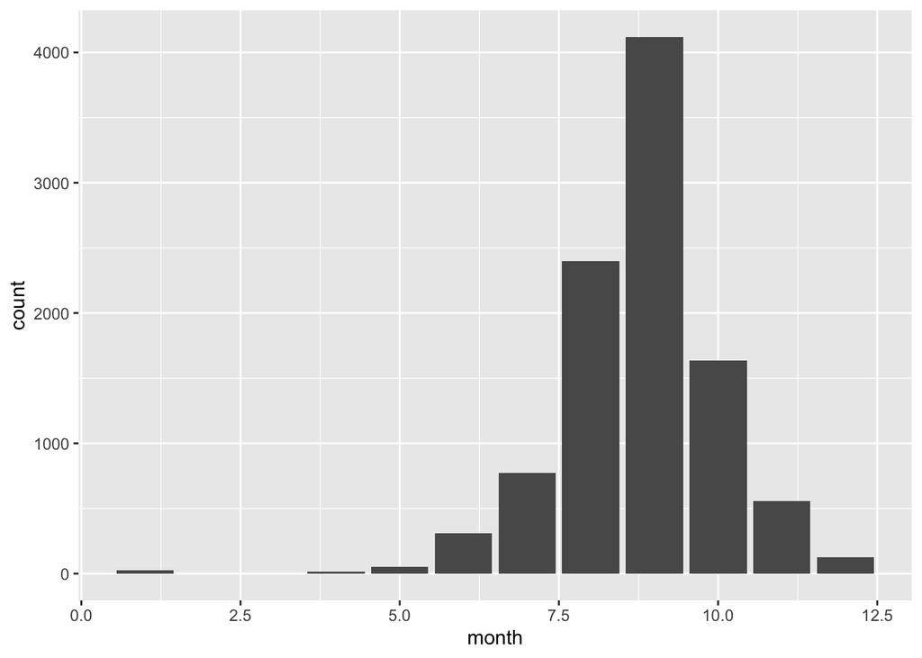

```r
ggplot(data = storms) +
  geom_bar(aes(x = month))
```

10. Does the plot make sense, or do you think there’s a problem with how we’re handling the data? Why?

11. Now let’s personalize your plot. Look at the cheatsheet for ggplot and locate the information for `geom_bar()`. Find out how to specify: border `color`, `fill` color. Also, see what happens when you specify `alpha = 0.5`.

alpha=0.5 makes the plot fill color lighter

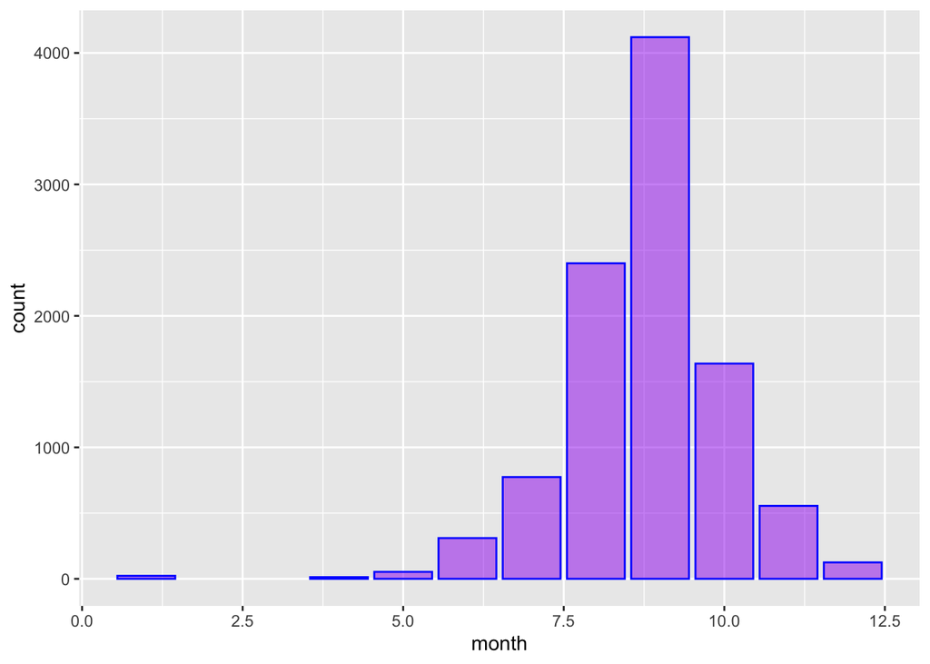

```r
ggplot(data=storms, (aes(x=month))) +
  geom_bar(color="blue", fill="purple", alpha=0.5)
```

12. Look at the cheatsheet for ggplot and locate the information for background *Themes*, e.g. `theme_bw()`. Find out how to add theme `theme_classic()` to the previous barchart.

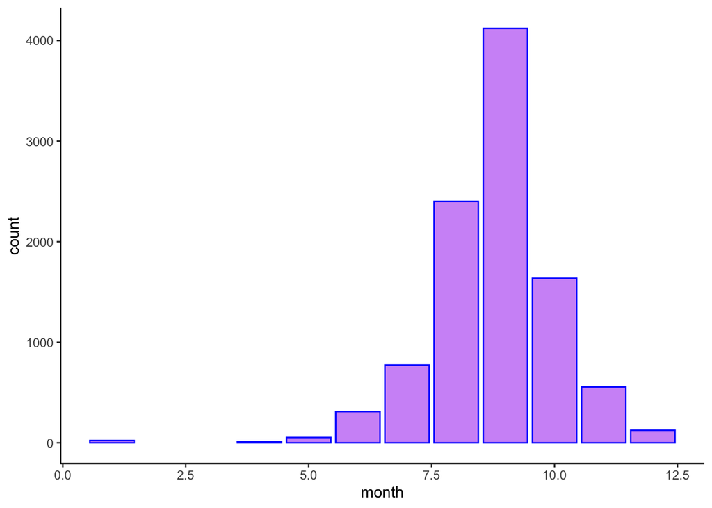

```r
ggplot(data=storms, (aes(x=month))) +
  geom_bar(color="blue", fill="purple", alpha=0.5)+
  theme_classic()
```

13. Let’s document your plot too. Look at the cheatsheet for ggplot and locate the information for *Labels*. Find out how to add a title with `ggtitle()` as well as with `labs()` to one of your previous barcharts.

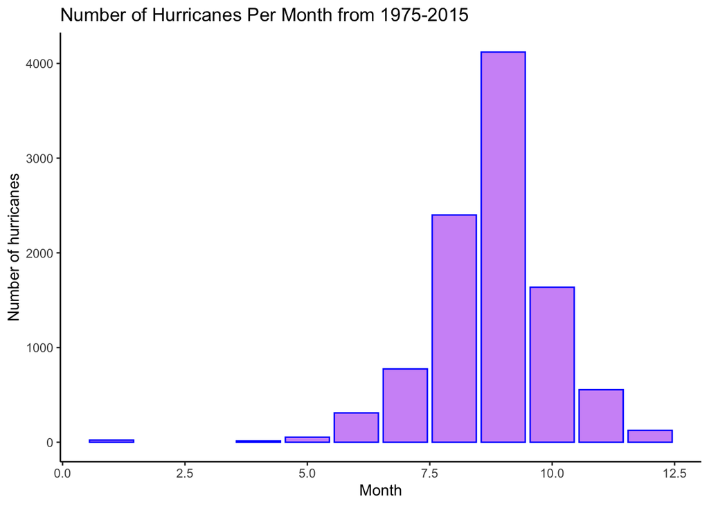

```r
ggplot(data=storms, (aes(x=month))) +
  geom_bar(color="blue", fill="purple", alpha=0.5)+
  theme_classic()+
  ggtitle("Number of Hurricanes Per Month from 1975-2015")+
  labs(x="Month", y= "Number of hurricanes")
```